# Lab 7

Author

Donya Behroozi

# Data Exploration

## Load libraries and read in data

```python
import pandas as pd
import numpy as np
from sklearn.pipeline import Pipeline
from sklearn.compose import ColumnTransformer
from sklearn.preprocessing import StandardScaler, MinMaxScaler
from sklearn.model_selection import cross_val_score
from sklearn.model_selection import GridSearchCV, StratifiedKFold, cross_val_predict
from sklearn.neighbors import KNeighborsClassifier
from sklearn.metrics import ConfusionMatrixDisplay, RocCurveDisplay, make_scorer, recall_score, roc_auc_score, precision_score, cohen_kappa_score, make_scorer
from sklearn.linear_model import LogisticRegression
from sklearn.feature_selection import SequentialFeatureSelector
from sklearn.tree import DecisionTreeClassifier
import matplotlib.pyplot as plt
from sklearn import tree
ha = pd.read_csv("https://www.dropbox.com/s/aohbr6yb9ifmc8w/heart_attack.csv?dl=1")
ha.head()
```

|  | age | sex | cp | trtbps | chol | restecg | thalach | output |
| --- | --- | --- | --- | --- | --- | --- | --- | --- |
| 0 | 63 | 1 | 3 | 145 | 233 | 0 | 150 | 1 |
| 1 | 37 | 1 | 2 | 130 | 250 | 1 | 187 | 1 |
| 2 | 56 | 1 | 1 | 120 | 236 | 1 | 178 | 1 |
| 3 | 57 | 0 | 0 | 120 | 354 | 1 | 163 | 1 |
| 4 | 57 | 1 | 0 | 140 | 192 | 1 | 148 | 1 |

## Summarize data

**Check for NAs:**

```python
ha.isna().sum()
```

```
age        0
sex        0
cp         0
trtbps     0
chol       0
restecg    0
thalach    0
output     0
dtype: int64
```

There are no NAs across any of the variables.

**Describe variables:**

```python
ha[['age', 'trtbps', 'chol', 'thalach']].describe()
```

|  | age | trtbps | chol | thalach |
| --- | --- | --- | --- | --- |
| count | 273.000000 | 273.000000 | 273.000000 | 273.000000 |
| mean | 54.347985 | 132.098901 | 246.860806 | 149.446886 |
| std | 9.163134 | 17.700358 | 52.569726 | 23.240707 |
| min | 29.000000 | 94.000000 | 126.000000 | 71.000000 |
| 25% | 47.000000 | 120.000000 | 211.000000 | 133.000000 |
| 50% | 56.000000 | 130.000000 | 240.000000 | 152.000000 |
| 75% | 61.000000 | 140.000000 | 275.000000 | 166.000000 |
| max | 77.000000 | 200.000000 | 564.000000 | 202.000000 |

```python
print(ha.value_counts("cp"))
print(ha.value_counts("restecg"))
```

```
cp
0    128
2     81
1     44
3     20
Name: count, dtype: int64
restecg
1    139
0    130
2      4
Name: count, dtype: int64
```

**Data types:**

```python
ha.dtypes
```

```
age        int64
sex        int64
cp         int64
trtbps     int64
chol       int64
restecg    int64
thalach    int64
output     int64
dtype: object
```

The numeric variable types are as expected. I will transform chest pain type and resting electrocardiographic results to dummy variables.

```python
ha['cp'] = ha['cp'].astype('object')
ha['restecg'] = ha['restecg'].astype('object')

ha = pd.get_dummies(ha)*1
ha.head()
```

|  | age | sex | trtbps | chol | thalach | output | cp_0 | cp_1 | cp_2 | cp_3 | restecg_0 | restecg_1 | restecg_2 |
| --- | --- | --- | --- | --- | --- | --- | --- | --- | --- | --- | --- | --- | --- |
| 0 | 63 | 1 | 145 | 233 | 150 | 1 | 0 | 0 | 0 | 1 | 1 | 0 | 0 |
| 1 | 37 | 1 | 130 | 250 | 187 | 1 | 0 | 0 | 1 | 0 | 0 | 1 | 0 |
| 2 | 56 | 1 | 120 | 236 | 178 | 1 | 0 | 1 | 0 | 0 | 0 | 1 | 0 |
| 3 | 57 | 0 | 120 | 354 | 163 | 1 | 1 | 0 | 0 | 0 | 0 | 1 | 0 |
| 4 | 57 | 1 | 140 | 192 | 148 | 1 | 1 | 0 | 0 | 0 | 0 | 1 | 0 |

# Part One: Fitting Models

**Define X and y**

```python
X = ha.drop(["output"], axis = 1)
y = ha["output"]
```

```python
X.head()
```

|  | age | sex | trtbps | chol | thalach | cp_0 | cp_1 | cp_2 | cp_3 | restecg_0 | restecg_1 | restecg_2 |
| --- | --- | --- | --- | --- | --- | --- | --- | --- | --- | --- | --- | --- |
| 0 | 63 | 1 | 145 | 233 | 150 | 0 | 0 | 0 | 1 | 1 | 0 | 0 |
| 1 | 37 | 1 | 130 | 250 | 187 | 0 | 0 | 1 | 0 | 0 | 1 | 0 |
| 2 | 56 | 1 | 120 | 236 | 178 | 0 | 1 | 0 | 0 | 0 | 1 | 0 |
| 3 | 57 | 0 | 120 | 354 | 163 | 1 | 0 | 0 | 0 | 0 | 1 | 0 |
| 4 | 57 | 1 | 140 | 192 | 148 | 1 | 0 | 0 | 0 | 0 | 1 | 0 |

```python
y.head()
```

```
0    1
1    1
2    1
3    1
4    1
Name: output, dtype: int64
```

Note: For cross validation, I will be using stratified K-fold cross validation to ensure that classes of my response variable are represented equally in my folds.

## Q1: KNN

To choose the best pipeline for KNN, I will determine the best combination of variables, choice of scaling (standard vs. min/max), distance metric (Euclidean vs. Manhattan), and choice of k with hyperparameter tuning and a grid search. Feature combinations will be chosen based on a backward sequential feature selector, where feature combinations that result in the highest cross-validated AUC score will be used as the final variables in our model.

```python
#define column transformer that scales numeric variables
preprocessing = ColumnTransformer(
    transformers=[("scale", StandardScaler(), ['age','trtbps','chol','thalach'])],
    remainder="passthrough"
)


#define feature selector
feature_selector = SequentialFeatureSelector(
    estimator = KNeighborsClassifier(),
    direction = "backward",
    scoring = "roc_auc",
    cv = 5,
    n_jobs = -1
)

#define pipeline
KNN_pipeline = Pipeline([
    ("preprocessing", preprocessing),
    ("feature_selection", feature_selector),
    ("knn", KNeighborsClassifier())
])

#define parameter space
param_grid = {
    "preprocessing__scale":[StandardScaler(), MinMaxScaler()], #choice of scaler
    "feature_selection__n_features_to_select": list(range(1,11+1)), #choice of features
    "knn__n_neighbors": list(range(1,20+1)), #choice of k
    "knn__p": [1,2], #choice of distance (1 = Manhattan, 2 = Euclidean)
}

cv = StratifiedKFold(n_splits=10, shuffle=True, random_state=321)

#perform grid search
grid_search = GridSearchCV(
    KNN_pipeline,
    param_grid = param_grid,
    scoring = "roc_auc",
    cv = cv,
    n_jobs = -1
)

grid_search.fit(X, y)
feature_names = grid_search.best_estimator_.named_steps["preprocessing"].get_feature_names_out()
mask = grid_search.best_estimator_.named_steps["feature_selection"].get_support()
print("Best AUC:", grid_search.best_score_)
print("Best params:", grid_search.best_params_)
print("Best features:", feature_names[mask])
```

```
Best AUC: 0.843943833943834
Best params: {'feature_selection__n_features_to_select': 10, 'knn__n_neighbors': 6, 'knn__p': 1, 'preprocessing__scale': MinMaxScaler()}
Best features: ['scale__age' 'scale__trtbps' 'scale__thalach' 'remainder__sex'
 'remainder__cp_0' 'remainder__cp_1' 'remainder__cp_3'
 'remainder__restecg_0' 'remainder__restecg_1' 'remainder__restecg_2']
```

The best KNN model is the model using a **min/max scaler**, **age, resting blood pressure, maximum heart rate achieved during exercise, sex, chest pain types 0, 1, and 3**, and **resting electrocardiographic results 0, 1, and 2** as features, **manhattan distance** as the distance metric, and **k = 6** due to having the highest cross-validated **AUC score = 0.844**.

**Define final best KNN pipeline:**

```python
#redefine X for KNN based on final selected features
X_KNN = ha[['age','trtbps', 'thalach', 'sex', 'cp_0', 'cp_1', 'cp_3', 'restecg_0', 'restecg_1', 'restecg_2']]

#KNN column transformer
KNN_preprocessing = ColumnTransformer(
    transformers=[("scale", MinMaxScaler(), ['age','trtbps','thalach'])],
    remainder="passthrough"
)

KNN_pipeline_final = Pipeline([
    ("preprocessing", KNN_preprocessing),
    ("knn", KNeighborsClassifier(n_neighbors = 6, p = 1))
])
```

**Confusion matrix:**

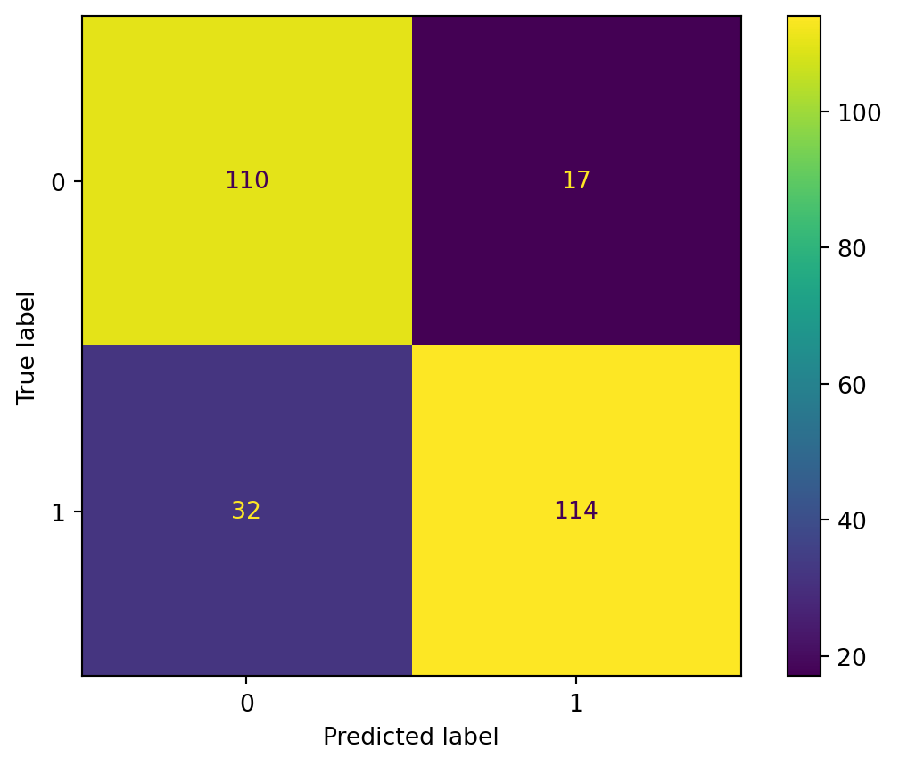

```python
#make predictions of output
KNN_fitted = KNN_pipeline_final.fit(X_KNN, y)

#output confusion matrix
ConfusionMatrixDisplay.from_estimator(KNN_fitted, X_KNN, y)
```

## Q2: Logistic Regression

To choose the best logistic regression model, I will fine tune the LASSO penalty parameter to perform automatic feature selection. I will also test whether using standard scaling or min/max scaling results in the higher AUC score.

```python
#define column transformer that scales numeric variables
preprocessing = ColumnTransformer(
    transformers=[("scale", StandardScaler(), ['age','trtbps','chol','thalach'])],
    remainder="passthrough"
)

#define pipeline
logit_pipeline = Pipeline(
    [
        ("preprocessing", preprocessing),
        ("logit_regression", LogisticRegression(solver = "liblinear", max_iter=5000))
    ]
)

#define parameter space
param_grid = {
    "preprocessing__scale":[StandardScaler(), MinMaxScaler()], #choice of scaler
    "logit_regression__penalty":["l1"], #lasso penalty
    "logit_regression__C":[0.001, 0.01, 0.1, 1, 10], #regularization strength
    "logit_regression__solver":["liblinear"]
}

#perform grid search
grid_search = GridSearchCV(
    logit_pipeline,
    param_grid=param_grid,
    scoring="roc_auc",
    cv=10
)

grid_search.fit(X, y)
print("Best AUC:", grid_search.best_score_)
print("Best params:", grid_search.best_params_)
```

```
Best AUC: 0.867887667887668
Best params: {'logit_regression__C': 10, 'logit_regression__penalty': 'l1', 'logit_regression__solver': 'liblinear', 'preprocessing__scale': StandardScaler()}
```

**Define final logistic regression model and obtain coefficients:**

```python
#logistic regression column transformer
logit_preprocessing = ColumnTransformer(
    transformers=[("scale", StandardScaler(), ['age','trtbps','thalach', 'chol'])],
    remainder="passthrough"
)

logit_pipeline_final = Pipeline(
    [
        ("preprocessing", logit_preprocessing),
        ("logit_regression", LogisticRegression(solver="liblinear", penalty="l1", C = 10))
    ]
)

logit_pipeline_fitted = logit_pipeline_final.fit(X, y)
logit_coefs = logit_pipeline_fitted.named_steps['logit_regression'].coef_
logit_coef_names = logit_pipeline_fitted.named_steps["preprocessing"].get_feature_names_out()
logit_coef_df = pd.DataFrame({"Variable": logit_coef_names, "Coef": logit_coefs[0]})
logit_coef_df
```

|  | Variable | Coef |
| --- | --- | --- |
| 0 | scale__age | -0.239660 |
| 1 | scale__trtbps | -0.347655 |
| 2 | scale__thalach | 0.790786 |
| 3 | scale__chol | -0.303139 |
| 4 | remainder__sex | -2.196404 |
| 5 | remainder__cp_0 | -1.928253 |
| 6 | remainder__cp_1 | 0.291044 |
| 7 | remainder__cp_2 | 0.090182 |
| 8 | remainder__cp_3 | 0.000000 |
| 9 | remainder__restecg_0 | 0.550797 |
| 10 | remainder__restecg_1 | 0.891260 |
| 11 | remainder__restecg_2 | 0.000000 |

After performing a grid search, I found the best logistic regression model to be the one that includes a lasso penalty with **regularization strength = 10**, **predictors age, resting blood pressure, maximum heart rate achieved during exercise, cholesterol, sex, chest pain types 0, 1, and 2, and resting electrographic results 0 and 1** and uses **standard scaling** of numeric variables due to having the highest cross-validated **AUC score = 0.868**.

**Confusion matrix:**

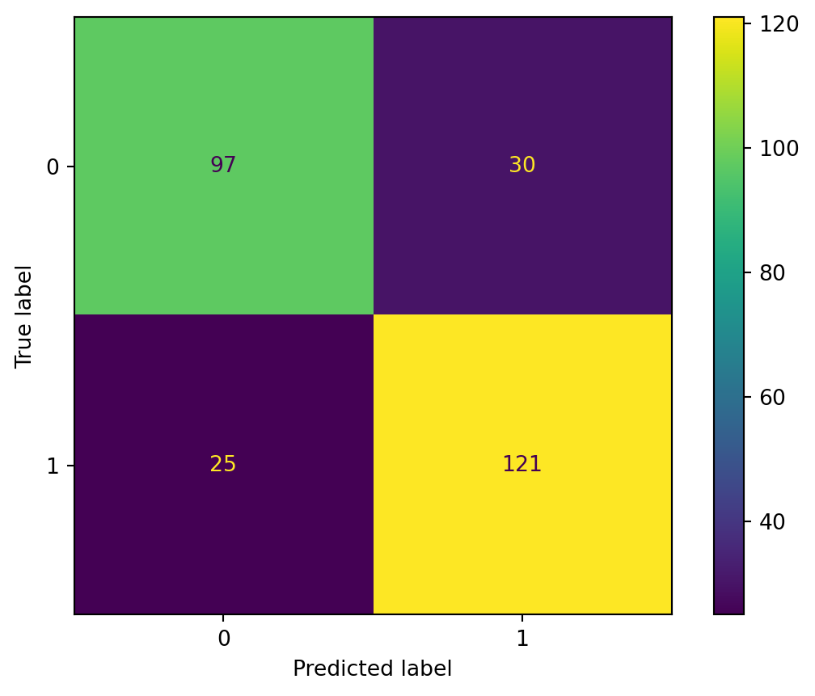

```python
#make predictions of output
logit_fitted = logit_pipeline_final.fit(X, y)

#output confusion matrix
ConfusionMatrixDisplay.from_estimator(logit_fitted, X, y)
```

## Q3: Decision Tree

To find the best pipeline for my decision tree, I will be using hyperparameter tuning to determine the best values of the cost complexity parameter, max depth, and minimum number of samples required to be in the tree’s leaf nodes.

```python
dt = DecisionTreeClassifier(random_state = 321)

paramGrid = {
    'ccp_alpha': dt.cost_complexity_pruning_path(X, y).ccp_alphas,
    'max_depth': range(1, 10+1),
    'min_samples_leaf': range(1, 10+1)
}

grid_search = GridSearchCV(dt,
                      paramGrid,
                      cv = cv,
                      scoring = 'roc_auc',
                      n_jobs = -1)

grid_search.fit(X, y)
print("Best AUC:", grid_search.best_score_)
print("Best params:", grid_search.best_params_)
```

```
Best AUC: 0.8271794871794871
Best params: {'ccp_alpha': np.float64(0.0023644785549547438), 'max_depth': 4, 'min_samples_leaf': 8}
```

**Display tree:**

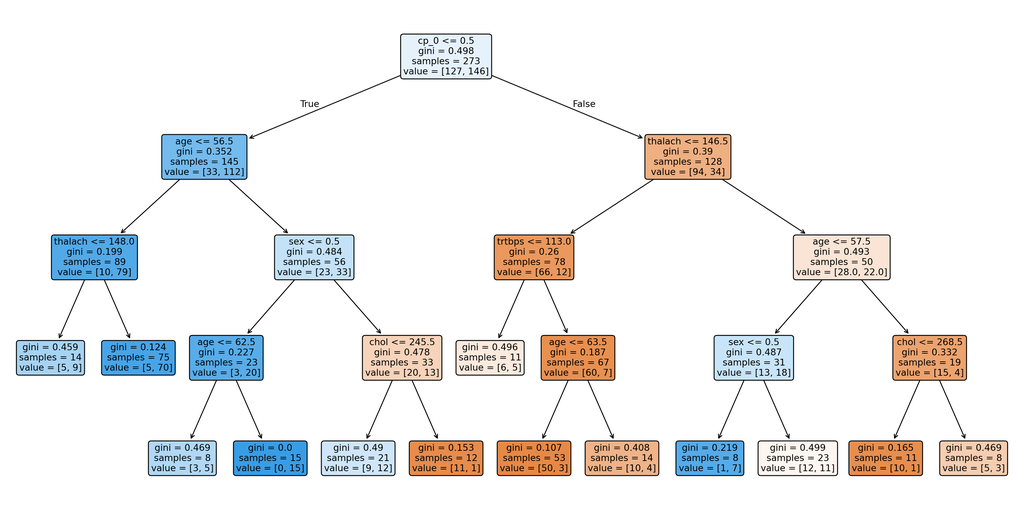

```python
plt.figure(figsize=(20,10))
dt_final = grid_search.best_estimator_
tree.plot_tree(dt_final, feature_names = X.columns, filled = True, rounded = True, fontsize = 10);
```

The best decision tree model is the model with a **cost complexity parameter of 0.002**, **max depth of 4**, **8 minimum samples per leaf**, and **chest pain type 0, maximum heart rate achieved during exercise, age, sex, resting blood pressure**, and **cholesterol** as features due to having the highest cross-validated **AUC score = 0.827**.

**Confusion matrix:**

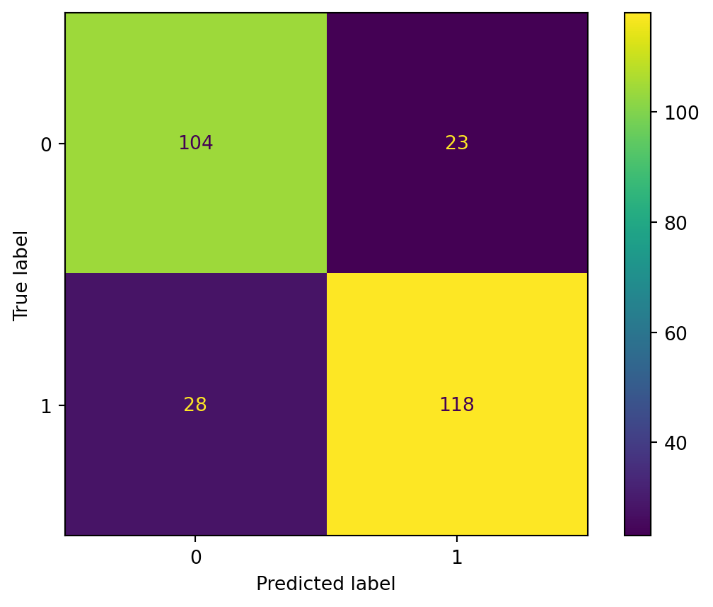

```python
#make predictions of output
dt_fitted = dt_final.fit(X, y)

#output confusion matrix
ConfusionMatrixDisplay.from_estimator(dt_fitted, X, y)
```

## Q4 Interpretation

Across all three models, the predictors that were most important to predicting heart attack risk include age, resting blood pressure, maximum heart rate achieved during exercise, sex, and chest pain type 0 (asymptomatic) as these variables appeared in each model’s final feature sets.

## Q5: ROC Curve

**KNN**

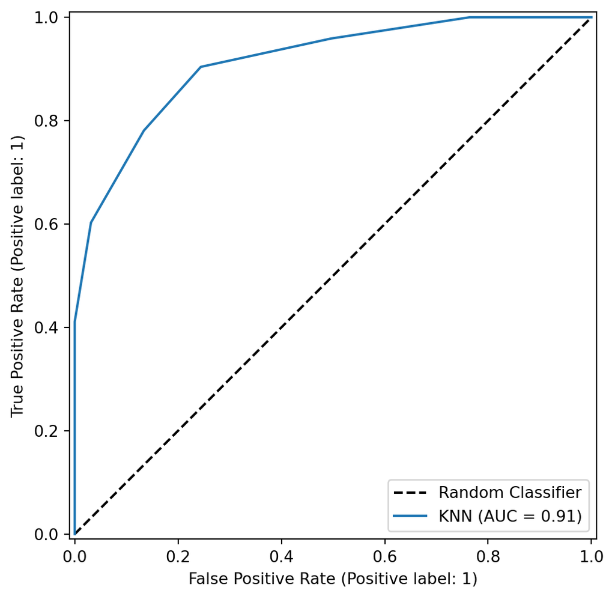

```python
fig, ax = plt.subplots(figsize = (6,6))

#roc curve for random classifier
ax.plot([0, 1], [0, 1], ls="--", c="k", label = "Random Classifier")

#generate roc curve for KNN model
RocCurveDisplay.from_estimator(KNN_fitted, X, y, ax = ax, name = "KNN")
```

**Logistic Regression**

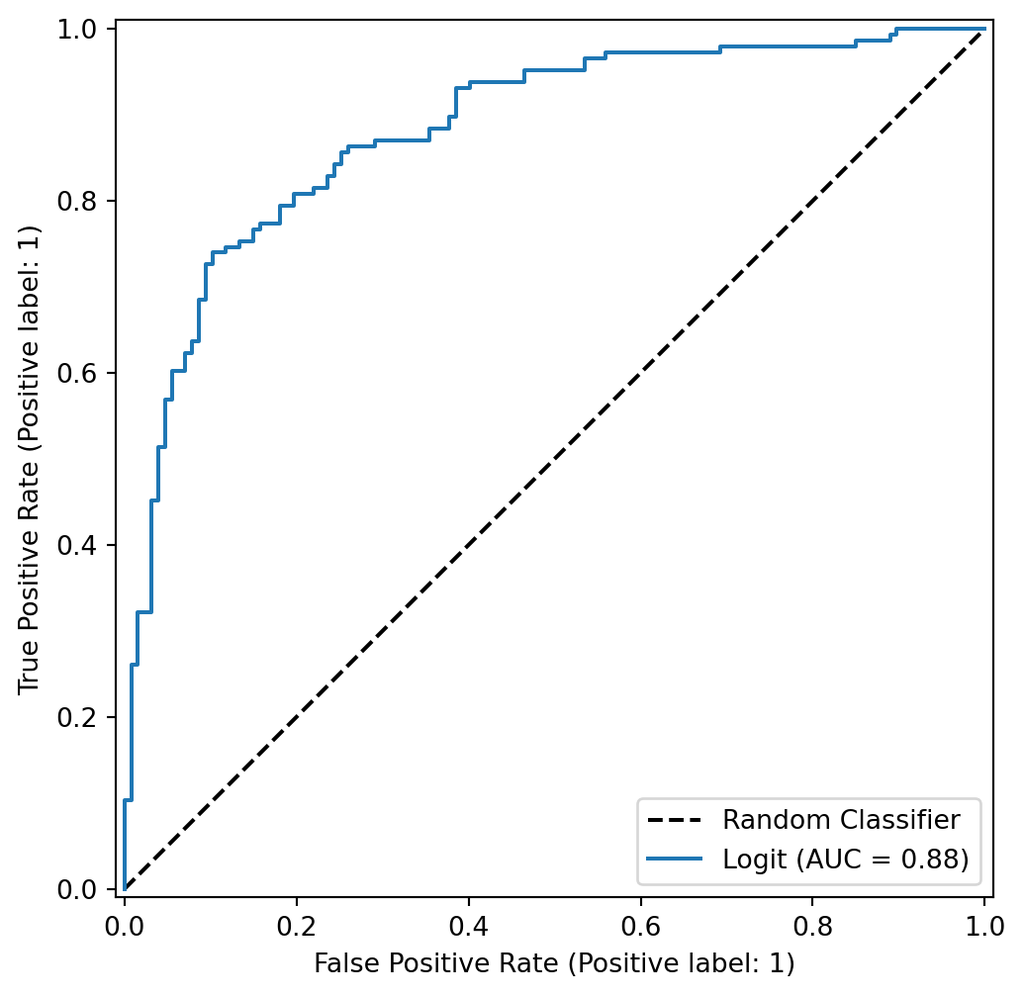

```python
fig, ax = plt.subplots(figsize = (6,6))

#roc curve for random classifier
ax.plot([0, 1], [0, 1], ls="--", c="k", label = "Random Classifier")

#generate roc curve for KNN model
RocCurveDisplay.from_estimator(logit_fitted, X, y, ax = ax, name = "Logit")
```

**Decision Tree**

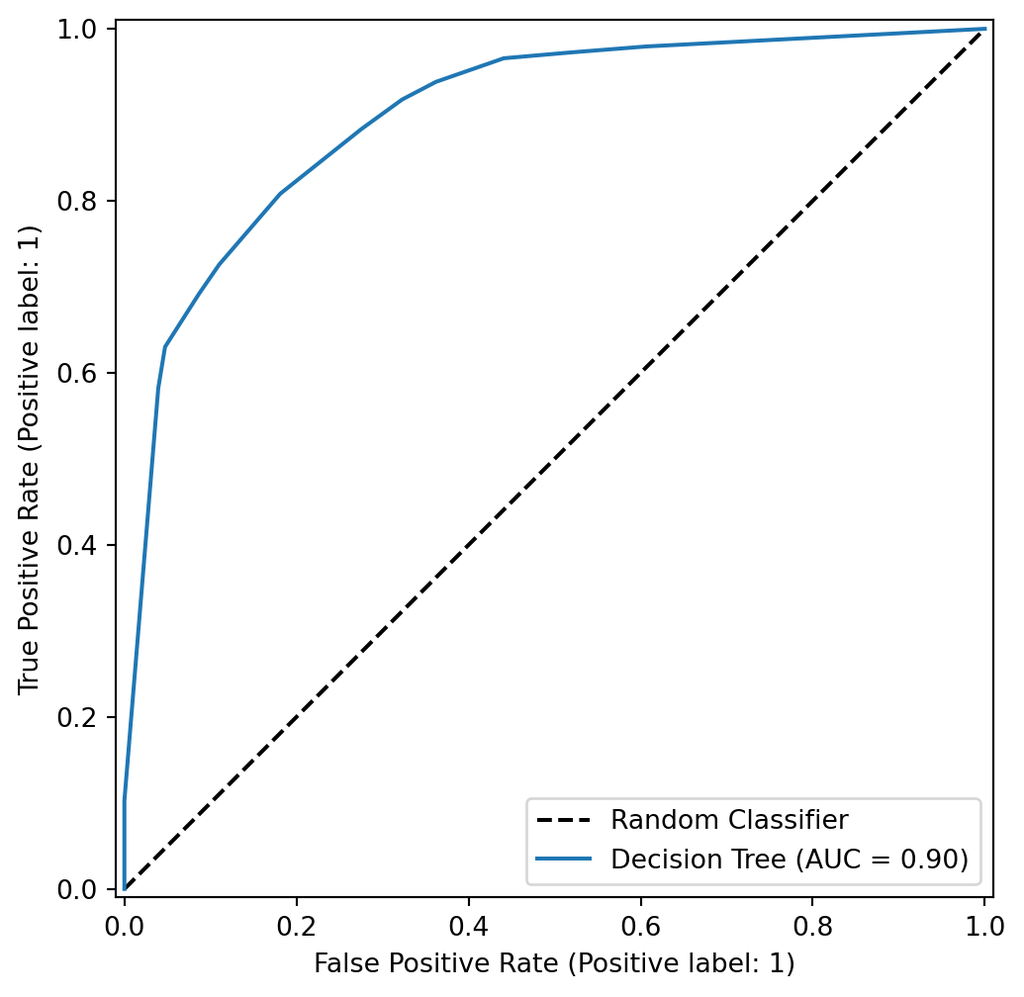

```python
fig, ax = plt.subplots(figsize = (6,6))

#roc curve for random classifier
ax.plot([0, 1], [0, 1], ls="--", c="k", label = "Random Classifier")

#generate roc curve for KNN model
RocCurveDisplay.from_estimator(dt_fitted, X, y, ax = ax, name = "Decision Tree")
```

# Part Two: Metrics

**KNN model**

```python
#recall
recall_KNN = cross_val_score(KNN_pipeline_final, X_KNN, y,
                cv=cv, scoring="recall").mean()

#precision
precision_KNN = cross_val_score(KNN_pipeline_final, X_KNN, y,
                cv=cv, scoring="precision").mean()

#specificity
specificity = make_scorer(recall_score, pos_label=0)
specificity_KNN = cross_val_score(KNN_pipeline_final, X_KNN, y,
                cv=cv, scoring=specificity).mean()

print("Recall: {}\nPrecision: {}\nSpecificity: {}".format(round(recall_KNN, 3), round(precision_KNN, 3), round(specificity_KNN, 3)))
```

```
Recall: 0.76
Precision: 0.812
Specificity: 0.794
```

**Logistic Regression model**

```python
#recall
recall_logit = cross_val_score(logit_pipeline_final, X, y,
                cv=cv, scoring="recall").mean()

#precision
precision_logit = cross_val_score(logit_pipeline_final, X, y,
                cv=cv, scoring="precision").mean()

#specificity
specificity = make_scorer(recall_score, pos_label=0)
specificity_logit = cross_val_score(logit_pipeline_final, X, y,
                cv=cv, scoring=specificity).mean()

print("Recall: {}\nPrecision: {}\nSpecificity: {}".format(round(recall_logit, 3), round(precision_logit, 3), round(specificity_logit, 3)))
```

```
Recall: 0.821
Precision: 0.79
Specificity: 0.74
```

**Decision Tree model**

```python
#recall
recall_dt = cross_val_score(dt_final, X, y,
                cv=cv, scoring="recall").mean()

#precision
precision_dt = cross_val_score(dt_final, X, y,
                cv=cv, scoring="precision").mean()

#specificity
specificity = make_scorer(recall_score, pos_label=0)
specificity_dt = cross_val_score(dt_final, X, y,
                cv=cv, scoring=specificity).mean()

print("Recall: {}\nPrecision: {}\nSpecificity: {}".format(round(recall_dt, 3), round(precision_dt, 3), round(specificity_dt, 3)))
```

```
Recall: 0.734
Precision: 0.78
Specificity: 0.758
```

# Part Three: Discussion

**Q1**

A patient that is deemed low risk who later experiences a heart attack is called a false negative. Since the hospital faces severe lawsuits if their false negative rate is high, we should choose the model with the **lowest false negative rate/1-sensitivity**.

```python
false_neg_KNN = 1 - recall_KNN
false_neg_logit = 1 - recall_logit
false_neg_dt = 1 - recall_dt

print("False Negative KNN: {}\nFalse Negative Logit: {}\nFalse Negative Decision Tree: {}".format(round(false_neg_KNN, 3), round(false_neg_logit,3), round(false_neg_dt,3)))
```

```
False Negative KNN: 0.24
False Negative Logit: 0.179
False Negative Decision Tree: 0.266
```

I would recommend the **logistic regression model** to the hospital due to having the lowest false negative rate. The hospital should expect a false negative rate of **17.9%** based on this model.

**Q2**

Since the hospital only wants to use bed space for patients most in need of monitoring due to heart attack risk, we should use the model with the highest **precision**. If we go with a model with low precision, we would be unnecessarily subjecting patients who are not at risk of heart attacks to undergo further medical tests and treatments (false positives).

```python
print("Precision KNN: {}\nPrecision Logit: {}\nPrecision Decision Tree: {}".format(round(precision_KNN, 3), round(precision_logit,3), round(precision_dt,3)))
```

```
Precision KNN: 0.812
Precision Logit: 0.79
Precision Decision Tree: 0.78
```

I would recommend the **KNN model** to the hospital due to having the highest precision. The hospital should expect a precision value of **0.812** based on this model.

**Q3**

For understanding which biological measures are associated with heart attack risk, I would recommend using the **logistic regression model**, as this model provides interpretable estimates of the variable coefficients. Regarding metrics, I would use the logistic regression model that gives me the highest **AUC score** in order to obtain the model with the best discriminative ability. This ensures that the model we choose is able to meaningfully discern heart attack vs. non-heart attack patients, and that our model’s coefficients can be trusted.

The hospital should expect an AUC score around **0.868** if they choose the logistic regression model.

**Q4**

Since the hospital would be training new doctors with the model we choose, I would recommend using the model with the highest overall **accuracy score**. Accuracy score is a useful metric when misclassification costs are symmetric for both target and nontarget cases. It seems like the doctors are not concerned with making specific mistakes, just the accuracy of their predictions.

```python
accuracy_KNN = cross_val_score(KNN_pipeline_final, X_KNN, y,
                            cv=cv, scoring="accuracy").mean()

accuracy_logit = cross_val_score(logit_pipeline_final, X, y,
                            cv=cv, scoring="accuracy").mean()

accuracy_dt = cross_val_score(dt_final, X, y,
                            cv=cv, scoring="accuracy").mean()

print("Accuracy KNN: {}\nAccuracy Logit: {}\nAccuracy Decision Tree: {}".format(round(accuracy_KNN, 3), round(accuracy_logit,3), round(accuracy_dt,3)))
```

```
Accuracy KNN: 0.776
Accuracy Logit: 0.784
Accuracy Decision Tree: 0.743
```

Due to the **logistic regression model** having the highest accuracy score, I’d recommend the hospital use this model. The hospital should expect an accuracy score near **0.784** if they use this model.

# Part Four: Validation

Read in and transform new data:

```python
ha_validation = pd.read_csv("https://www.dropbox.com/s/jkwqdiyx6o6oad0/heart_attack_validation.csv?dl=1")
ha_validation['cp'] = ha_validation['cp'].astype('object')
ha_validation['restecg'] = ha_validation['restecg'].astype('object')

ha_validation = pd.get_dummies(ha_validation)*1
ha_validation['restecg_2'] = 0
ha_validation.head()
```

|  | age | sex | trtbps | chol | thalach | output | cp_0 | cp_1 | cp_2 | cp_3 | restecg_0 | restecg_1 | restecg_2 |
| --- | --- | --- | --- | --- | --- | --- | --- | --- | --- | --- | --- | --- | --- |
| 0 | 41 | 0 | 130 | 204 | 172 | 1 | 0 | 1 | 0 | 0 | 1 | 0 | 0 |
| 1 | 64 | 1 | 110 | 211 | 144 | 1 | 0 | 0 | 0 | 1 | 1 | 0 | 0 |
| 2 | 59 | 1 | 135 | 234 | 161 | 1 | 1 | 0 | 0 | 0 | 0 | 1 | 0 |
| 3 | 42 | 1 | 140 | 226 | 178 | 1 | 1 | 0 | 0 | 0 | 0 | 1 | 0 |
| 4 | 40 | 1 | 140 | 199 | 178 | 1 | 0 | 0 | 0 | 1 | 0 | 1 | 0 |

Define X and y with new data:

```python
X_validation = ha_validation.drop(["output"], axis = 1)
y_validation = ha_validation["output"]
```

```python
X_validation.head()
```

|  | age | sex | trtbps | chol | thalach | cp_0 | cp_1 | cp_2 | cp_3 | restecg_0 | restecg_1 | restecg_2 |
| --- | --- | --- | --- | --- | --- | --- | --- | --- | --- | --- | --- | --- |
| 0 | 41 | 0 | 130 | 204 | 172 | 0 | 1 | 0 | 0 | 1 | 0 | 0 |
| 1 | 64 | 1 | 110 | 211 | 144 | 0 | 0 | 0 | 1 | 1 | 0 | 0 |
| 2 | 59 | 1 | 135 | 234 | 161 | 1 | 0 | 0 | 0 | 0 | 1 | 0 |
| 3 | 42 | 1 | 140 | 226 | 178 | 1 | 0 | 0 | 0 | 0 | 1 | 0 |
| 4 | 40 | 1 | 140 | 199 | 178 | 0 | 0 | 0 | 1 | 0 | 1 | 0 |

```python
y_validation.head()
```

```
0    1
1    1
2    1
3    1
4    1
Name: output, dtype: int64
```

## Predicting y with KNN model

**Confusion matrix**

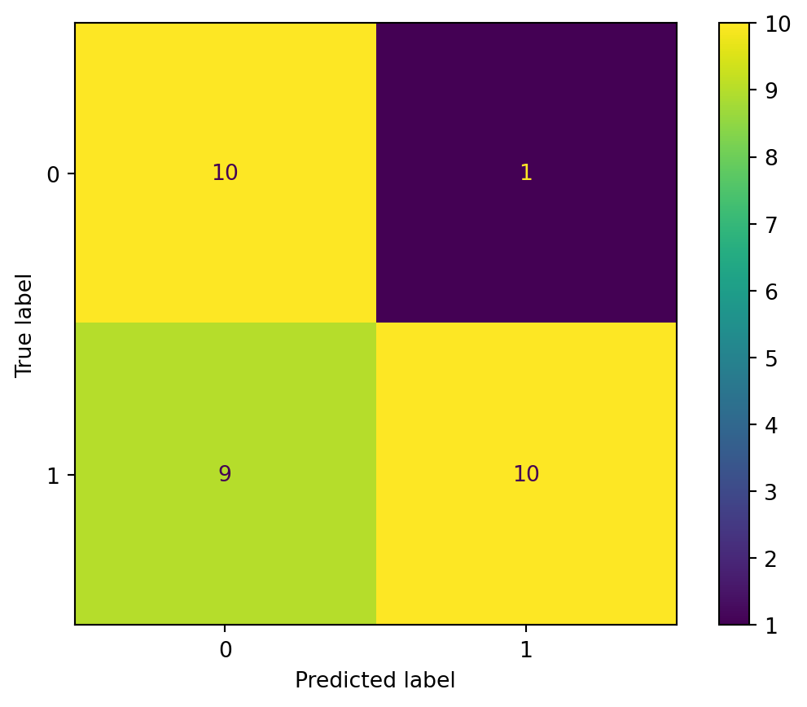

```python
X_KNN_validation = ha_validation[['age','trtbps', 'thalach', 'sex', 'cp_0', 'cp_1', 'cp_3', 'restecg_0', 'restecg_1', 'restecg_2']]

ConfusionMatrixDisplay.from_estimator(KNN_fitted, X_KNN_validation, y_validation)
```

**ROC AUC, precision, recall**

```python
y_pred_KNN_validation = KNN_fitted.predict(X_KNN_validation)
y_prob_KNN_validation = KNN_fitted.predict_proba(X_KNN_validation)[:, 1]

rocauc_KNN_validation = roc_auc_score(y_validation, y_prob_KNN_validation)
precision_KNN_validation = precision_score(y_validation, y_pred_KNN_validation)
recall_KNN_validation = recall_score(y_validation, y_pred_KNN_validation)

print("ROC AUC: {}\nPrecision: {}\nRecall: {}".format(round(rocauc_KNN_validation, 3), round(precision_KNN_validation, 3), round(recall_KNN_validation, 3)))
```

```
ROC AUC: 0.856
Precision: 0.909
Recall: 0.526
```

The ROC AUC is very similar to our cross-validated ROC AUC score for the KNN model reported in part 1 (0.844 vs. 0.856). Precision is higher than before (0.812 vs. 0.909), but recall has decreased quite a bit (0.76 vs. 0.526).

## Predicting y with logistic regression model

**Confusion matrix**

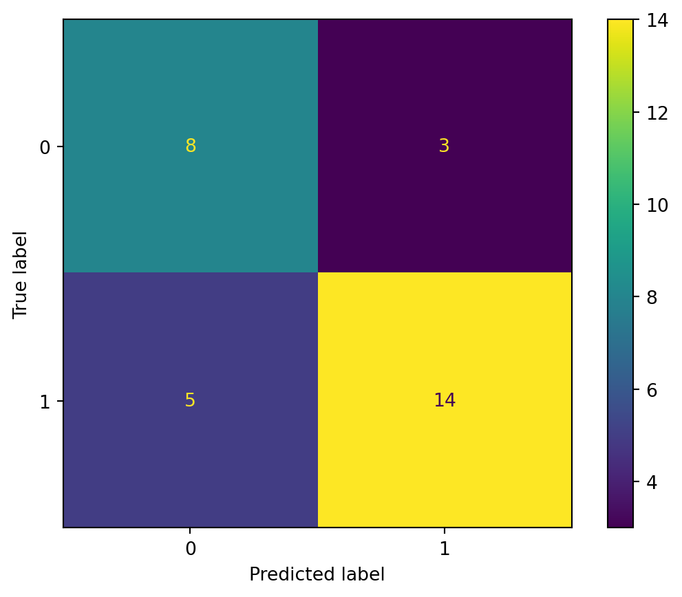

```python
ConfusionMatrixDisplay.from_estimator(logit_fitted, X_validation, y_validation)
```

**ROC AUC, precision, recall**

```python
y_pred_logit_validation = logit_fitted.predict(X_validation)
y_prob_logit_validation = logit_fitted.predict_proba(X_validation)[:, 1]

rocauc_logit_validation = roc_auc_score(y_validation, y_prob_logit_validation)
precision_logit_validation = precision_score(y_validation, y_pred_logit_validation)
recall_logit_validation = recall_score(y_validation, y_pred_logit_validation)

print("ROC AUC: {}\nPrecision: {}\nRecall: {}".format(round(rocauc_logit_validation, 3), round(precision_logit_validation, 3), round(recall_logit_validation, 3)))
```

```
ROC AUC: 0.885
Precision: 0.824
Recall: 0.737
```

The ROC AUC and recall scores are very similar to that of our cross-validated scores for the logistic regression model reported in part 1 (0.868 vs. 0.885 for ROC AUC; 0.821 vs. 0.824 for recall). Precision is slightly higher than before (0.79 vs. 0.824).

## Predicting y with decision tree model

**Confusion matrix**

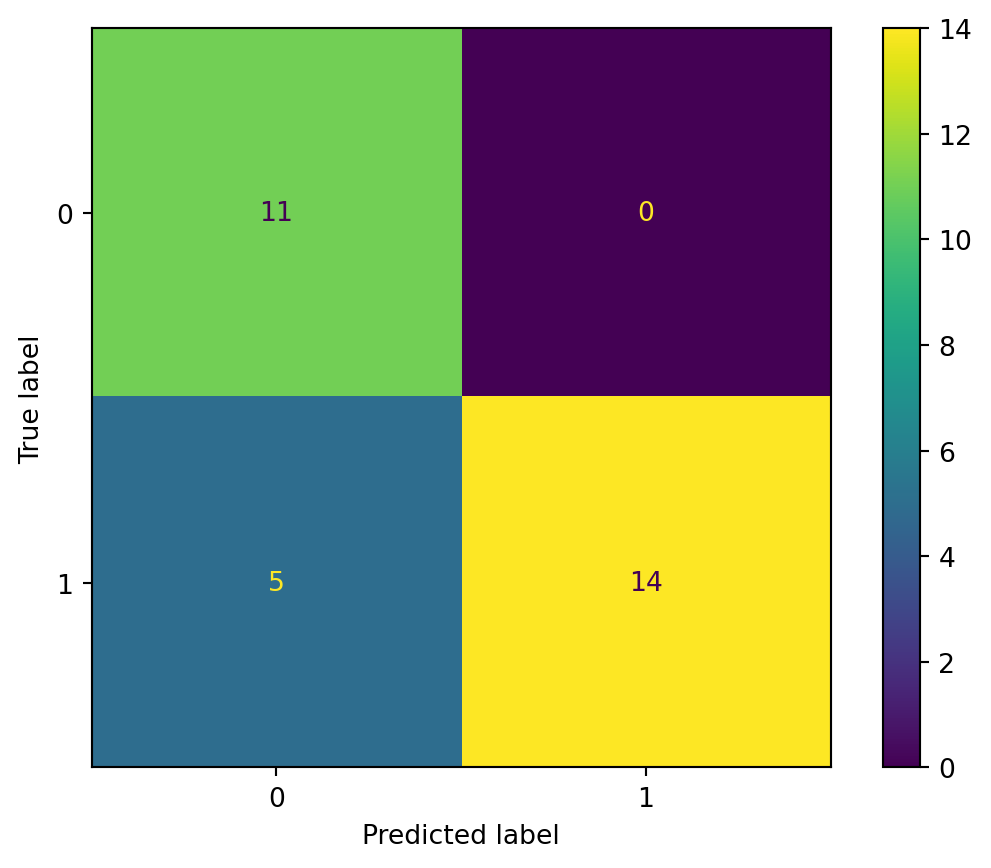

```python
ConfusionMatrixDisplay.from_estimator(dt_fitted, X_validation, y_validation)
```

**ROC AUC, precision, recall**

```python
y_pred_dt_validation = dt_fitted.predict(X_validation)
y_prob_dt_validation = dt_fitted.predict_proba(X_validation)[:, 1]

rocauc_dt_validation = roc_auc_score(y_validation, y_prob_dt_validation)
precision_dt_validation = precision_score(y_validation, y_pred_dt_validation)
recall_dt_validation = recall_score(y_validation, y_pred_dt_validation)

print("ROC AUC: {}\nPrecision: {}\nRecall: {}".format(round(rocauc_dt_validation, 3), round(precision_dt_validation, 3), round(recall_dt_validation, 3)))
```

```
ROC AUC: 0.902
Precision: 1.0
Recall: 0.737
```

The ROC AUC, precision, and recall scores are even better (higher) for the validation data than that of our cross-validated scores for the decision tree model (0.827 vs. 0.902 for ROC AUC; 0.78 vs. 1.0 for precision; 0.734 vs. 0.737 for recall).

Overall, I would say that the the measure of model success across all models did turn out to be approximately correct for the validation data.

# Part Five: Cohen’s Kappa

```python
kappa_KNN = cross_val_score(KNN_pipeline_final, X_KNN, y,
                cv=cv, scoring=make_scorer(cohen_kappa_score)).mean()

kappa_logit = cross_val_score(logit_pipeline_final, X, y,
                cv=cv, scoring=make_scorer(cohen_kappa_score)).mean()

kappa_dt = cross_val_score(dt_final, X, y,
                cv=cv, scoring=make_scorer(cohen_kappa_score)).mean()

print("CK KNN: {}\nCK Logit: {}\nCK Decision Tree: {}".format(round(kappa_KNN, 3), round(kappa_logit, 3), round(kappa_dt, 3)))
```

```
CK KNN: 0.551
CK Logit: 0.563
CK Decision Tree: 0.488
```

Cohen’s Kappa is a statistic that measures the level of agreement between the classifications of raters/judges, accounting for the fact that the raters may agree on some classifications by chance. I believe that this statistic is highly useful for the situation mentioned in part three Q4:

The hospital is training a new batch of doctors, and they would like to compare the diagnoses of these doctors to the predictions given by the algorithm to measure the ability of new doctors to diagnose patients.

Using a Cohen’s Kappa for these types of situations would allow for the doctors in training to get a sense of how close in agreement their diagnoses are to the algorithm chosen rather than simply relying on overall model accuracy. Especially in a medical context, producing reproducible and consistent diagnoses is very important to accurately diagnosing patients.

If I were to use the highest Cohen’s Kappa value to choose the best model (logistic regression model), only my conclusion for Q2 in part three changes. It makes sense that the rest of the answers did not change, as in part four, I found that the logistic regression model’s cross-validated measures of model success were very close to that of the metrics for the validation data. Therefore, we would expect the largest Cohen’s Kappa for the logistic regression model as our predicted y values are in moderate agreement with our actual y values (logistic regression model has the highest overall accuracy score), and this result is consistent when applied to new data as well.